# AT embryo delayed development measurements

# Embryonic perimeter in males only

Imported only the male embryo measurements because the female sample size is much smaller. Delay observed in females, but occurs more sporadically.

```r
embryos <- read.csv("https://docs.google.com/spreadsheets/d/e/2PACX-1vRardz8DQxyjal-BQCrVOqgcEo2Rug6MRojf1h-yJxMPz6NCxl1SqHNmSZx44qS1AYn3_LwYYCtAvyj/pub?gid=260011419&single=true&output=csv")

embryos$Naa10.genotype <- as.factor(embryos$Naa10.genotype)
embryos$Litter.Theiler.stage <-as.factor(embryos$Litter.Theiler.stage)
head(embryos)
```

|  | ID | Litter | Litter.Theiler.stage | sex | Naa10.genotype | perimeter.1..µm. | perimeter.2..µm. | perimeter..µm. | perimeter..mm. | area..µm.2. | area..mm.2. | notes |
| --- | --- | --- | --- | --- | --- | --- | --- | --- | --- | --- | --- | --- |
| 1 | AT16-1 | AT-16 | TS15 | male | KO/Y | 7252.71 | 7204.12 | 7228.415 | 7.228415 | 1368553.0 | 1.3685530 |  |
| 2 | AT16-4 | AT-16 | TS15 | male | KO/Y | 6102.70 | 7113.65 | 6608.175 | 6.608175 | 121793.8 | 0.1217938 | missing tail? |
| 3 | AT16-3 | AT-16 | TS15 | male | KO/Y | 4500.26 | 4800.59 | 4650.425 | 4.650425 | 687575.2 | 0.6875752 |  |
| 4 | AT19-5 | AT-19 | TS16 | male | WT/Y | 9856.92 | 9697.89 | 9777.405 | 9.777405 | 3377022.1 | 3.3770221 |  |
| 5 | AT19-6 | AT-19 | TS16 | male | KO/Y | 11560.38 | 12073.72 | 11817.050 | 11.817050 | 4348595.9 | 4.3485959 | elongated during photography |
| 6 | AT19-9 | AT-19 | TS16 | male | WT/Y | 22988.84 | 24133.91 | 23561.375 | 23.561375 | 15904554.4 | 15.9045544 |  |

```r
structure(embryos$area)
```

```r
install.packages("tidyverse",repos='http://cran.us.r-project.org')
```

```r
install.packages("ggplot2",repos='http://cran.us.r-project.org')
install.packages("Rmisc",repos='http://cran.us.r-project.org')
```

## Perimeter analysis

### Perimeter summary statistics

#### Grouped by Naa10 genotype and Litter Theiler stage

```r
library(Rmisc)
peri.summ <- summarySE(data = embryos, "perimeter..mm.",
          groupvars = c("Naa10.genotype","Litter.Theiler.stage"))
peri.summ
```

| Naa10.genotype | Litter.Theiler.stage | N | perimeter..mm. | sd | se | ci |
| --- | --- | --- | --- | --- | --- | --- |
| KO/Y | TS12 | 2 | 4.765783 | 0.04465026 | 0.0315725 | 0.4011666 |
| KO/Y | TS13 | 5 | 8.154738 | 2.04716829 | 0.9155215 | 2.5418952 |
| KO/Y | TS14 | 3 | 8.417277 | 0.77900208 | 0.4497571 | 1.9351484 |
| KO/Y | TS15 | 3 | 6.162338 | 1.34558012 | 0.7768710 | 3.3426063 |
| KO/Y | TS16 | 1 | 11.817050 | NA | NA | NA |
| KO/Y | TS17 | 1 | 9.688215 | NA | NA | NA |
| WT/Y | TS12 | 2 | 5.394390 | 0.02061216 | 0.0145750 | 0.1851929 |
| WT/Y | TS13 | 3 | 5.310013 | 0.93246257 | 0.5383575 | 2.3163654 |
| WT/Y | TS14 | 4 | 16.106621 | 3.45183772 | 1.7259189 | 5.4926441 |
| WT/Y | TS15 | 3 | 13.933908 | 2.23276409 | 1.2890869 | 5.5464935 |

[output cut: 3 more lines]

#### summary statistics by Naa10 genotype

```r
peri.summ1 <- summarySE(data = embryos, "perimeter..mm.",
          groupvars = c("Naa10.genotype"))

peri.summ1
```

| Naa10.genotype | N | perimeter..mm. | sd | se | ci |
| --- | --- | --- | --- | --- | --- |
| KO/Y | 15 | 7.703291 | 2.226356 | 0.5748426 | 1.232915 |
| WT/Y | 17 | 13.708161 | 7.133677 | 1.7301708 | 3.667798 |

#### summary statistics by Theiler stage

```r
peri.summ2 <- summarySE(data = embryos, "perimeter..mm.",
          groupvars = c("Litter.Theiler.stage"))
peri.summ2
```

| Litter.Theiler.stage | N | perimeter..mm. | sd | se | ci |
| --- | --- | --- | --- | --- | --- |
| TS12 | 4 | 5.080086 | 0.3640357 | 0.1820178 | 0.579262 |
| TS13 | 8 | 7.087966 | 2.1933642 | 0.7754713 | 1.833698 |
| TS14 | 7 | 12.811188 | 4.8013563 | 1.8147421 | 4.440514 |
| TS15 | 6 | 10.048123 | 4.5648131 | 1.8635771 | 4.790478 |
| TS16 | 4 | 17.607945 | 7.9392160 | 3.9696080 | 12.633064 |
| TS17 | 2 | 17.677727 | 11.2988769 | 7.9895125 | 101.516382 |
| TS18 | 1 | 15.809730 | NA | NA | NA |

### Linear model

#### TS and Naa10 genotype interaction

```r
install.packages("car",repos='http://cran.us.r-project.org')
library(car)
peri.int.lm <- lm(perimeter..mm. ~ Litter.Theiler.stage*Naa10.genotype, embryos)

aov(peri.int.lm)
```

```
## Call:
##    aov(formula = peri.int.lm)
##
## Terms:
##                 Litter.Theiler.stage Naa10.genotype
## Sum of Squares              577.6264       156.7150
## Deg. of Freedom                    6              1
##                 Litter.Theiler.stage:Naa10.genotype Residuals
## Sum of Squares                             223.1856  213.4367
## Deg. of Freedom                                   5        19
##
## Residual standard error: 3.351643
## 1 out of 14 effects not estimable
## Estimated effects may be unbalanced
```

```r
summary(aov(peri.int.lm))
```

```
##                                     Df Sum Sq Mean Sq F value   Pr(>F)
## Litter.Theiler.stage                 6  577.6   96.27   8.570 0.000136 ***
## Naa10.genotype                       1  156.7  156.71  13.951 0.001403 **
## Litter.Theiler.stage:Naa10.genotype  5  223.2   44.64   3.974 0.012325 *
## Residuals                           19  213.4   11.23
## ---
## Signif. codes:  0 '***' 0.001 '**' 0.01 '*' 0.05 '.' 0.1 ' ' 1
```

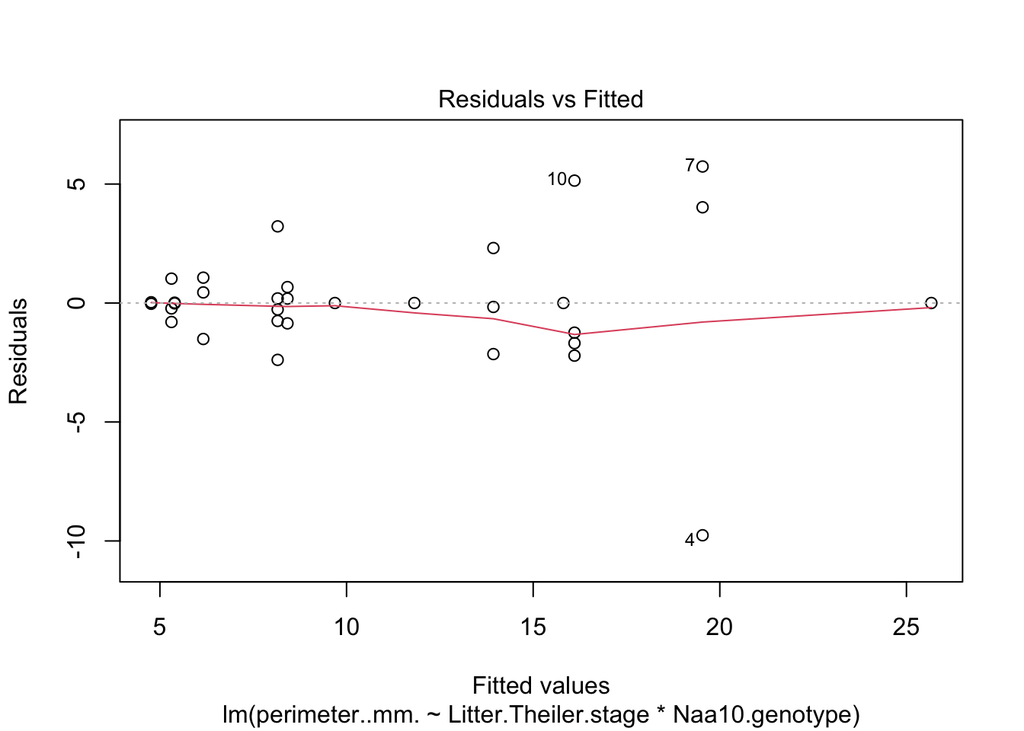

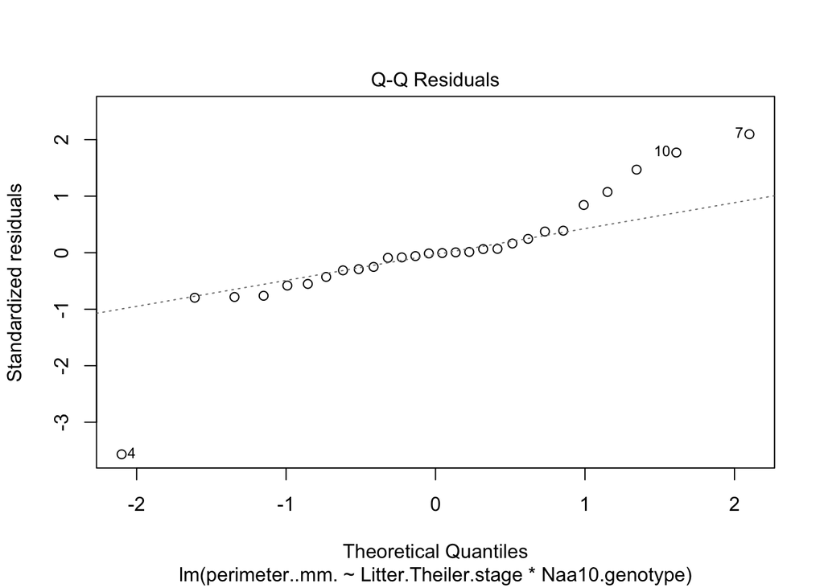

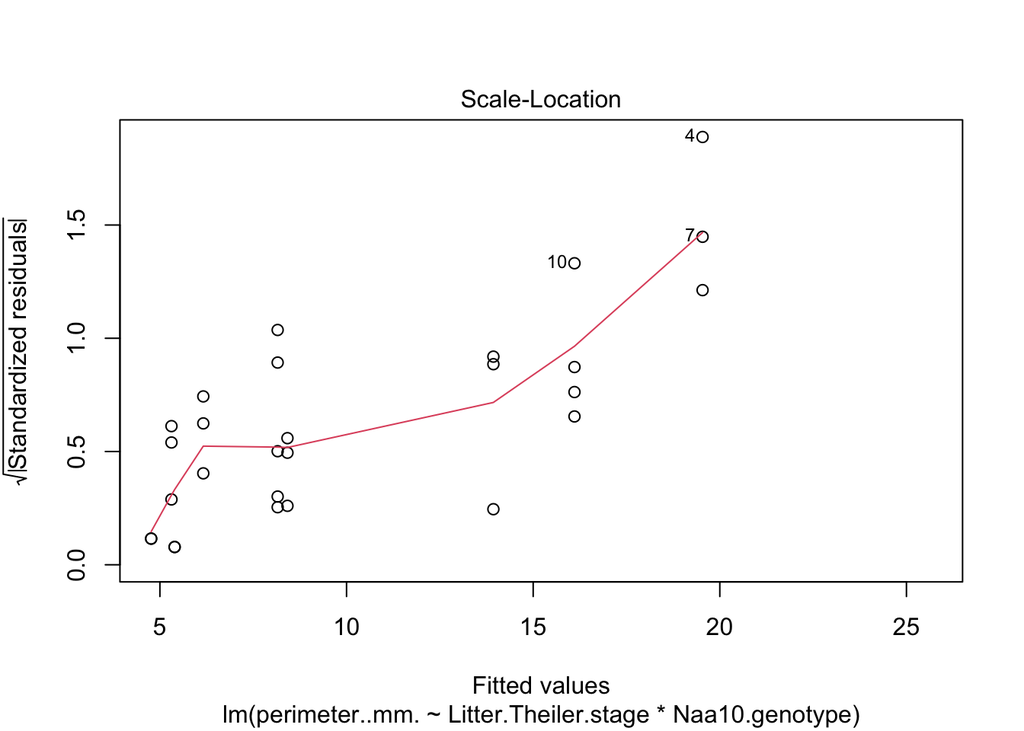

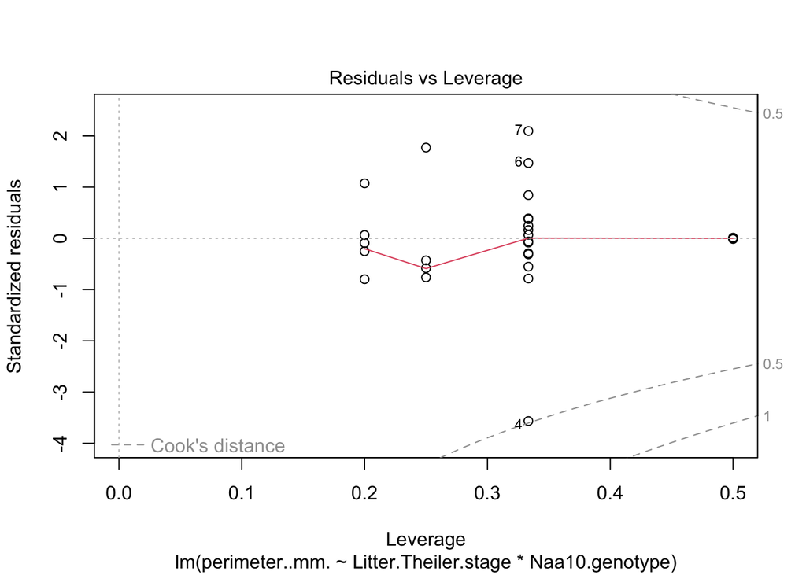

```r
plot(peri.int.lm)
```

```r
library(car)
Anova(peri.int.lm, type = "III",singular.ok = TRUE)
```

```
## Note: model has aliased coefficients
##       sums of squares computed by model comparison
```

|  | Sum Sq | Df | F values | Pr(>F) |
| --- | --- | --- | --- | --- |
| Litter.Theiler.stage | 47.7928027 | 5 | 0.85089703 | 0.53107098 |
| Naa10.genotype | 0.3951474 | 1 | 0.03517577 | 0.85321622 |
| Litter.Theiler.stage:Naa10.genotype | 223.1856105 | 5 | 3.97356843 | 0.01232474 |
| Residuals | 213.4366966 | 19 | NA | NA |

```r
#perimeter..mm. is colinear with one of the explanatory variables
```

Interaction between both variables is significant, so we can test each variable separately.

```r
install.packages("multcomp",repos='http://cran.us.r-project.org')
```

#### Variance when main effects of Naa10 genotype and TS are assessed separately

##### Naa10 genotype

```r
library(car)
peri.lm <- lm(perimeter..mm. ~ Litter.Theiler.stage+Naa10.genotype, embryos)
```

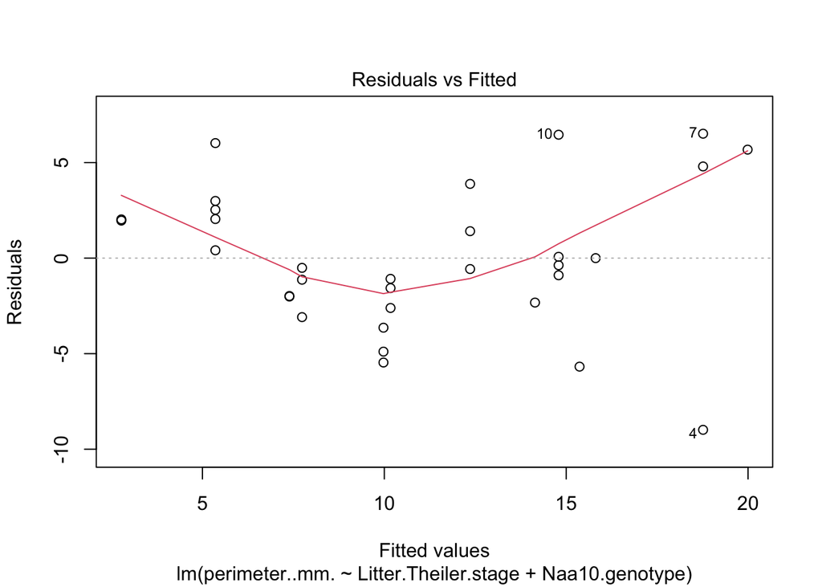

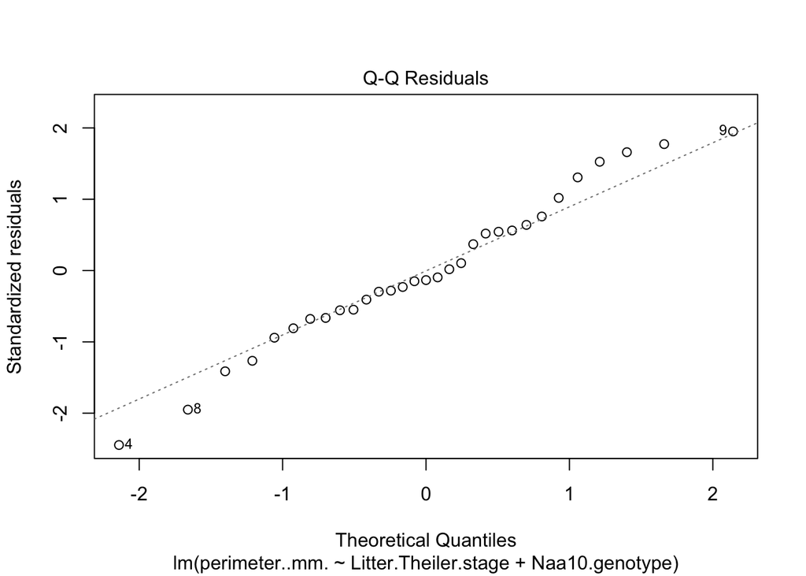

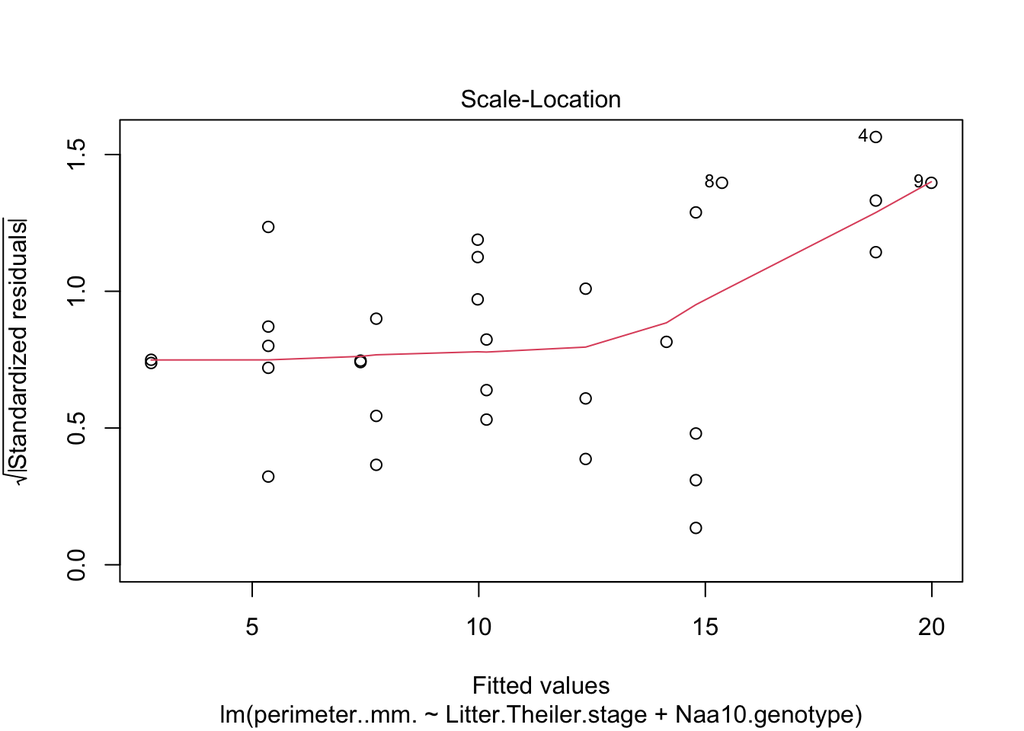

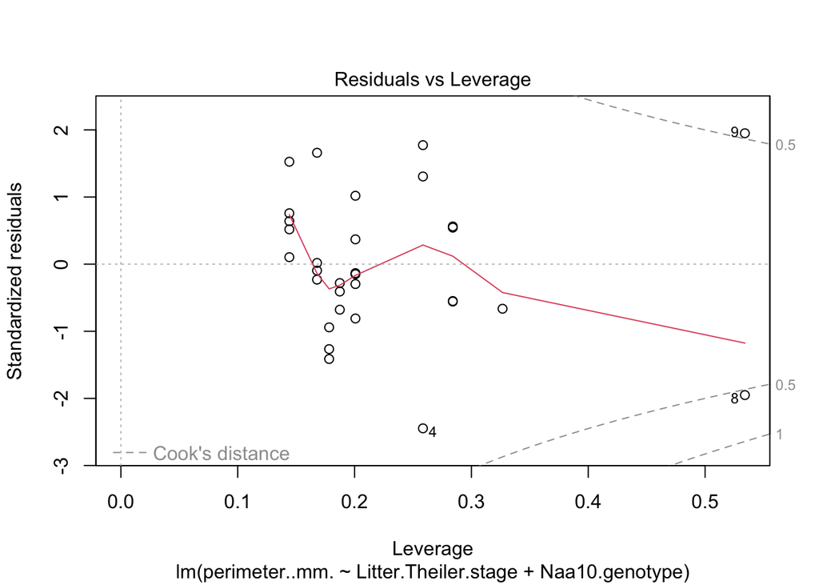

```r
plot(peri.lm)
```

```r
library(car)
Anova(peri.lm, type = "III",singular.ok = TRUE)
```

|  | Sum Sq | Df | F value | Pr(>F) |
| --- | --- | --- | --- | --- |
| (Intercept) | 27.00396 | 1 | 1.484338 | 0.234938704 |
| Litter.Theiler.stage | 447.00050 | 6 | 4.095077 | 0.005727085 |
| Naa10.genotype | 156.71498 | 1 | 8.614217 | 0.007238306 |
| Residuals | 436.62231 | 24 | NA | NA |

```r
library(multcomp)
ts.tukey <- glht(peri.lm,linfct = mcp(Litter.Theiler.stage = "Tukey"))
summary(ts.tukey)
```

```
##
##   Simultaneous Tests for General Linear Hypotheses
##
## Multiple Comparisons of Means: Tukey Contrasts
##
##
## Fit: lm(formula = perimeter..mm. ~ Litter.Theiler.stage + Naa10.genotype,
##     data = embryos)
##
## Linear Hypotheses:
##                  Estimate Std. Error t value Pr(>|t|)
## TS13 - TS12 == 0    2.585      2.619   0.987   0.9480
## TS14 - TS12 == 0    7.401      2.676   2.766   0.1164
## TS15 - TS12 == 0    4.968      2.753   1.804   0.5405
## TS16 - TS12 == 0   11.373      3.042   3.739   0.0139 *
## TS17 - TS12 == 0   12.598      3.694   3.410   0.0295 *
## TS18 - TS12 == 0    8.419      4.833   1.742   0.5795
## TS14 - TS13 == 0    4.816      2.229   2.160   0.3358
## TS15 - TS13 == 0    2.383      2.312   1.031   0.9368
## TS16 - TS13 == 0    8.787      2.678   3.281   0.0394 *
## TS17 - TS13 == 0   10.012      3.378   2.964   0.0776 .
## TS18 - TS13 == 0    5.834      4.630   1.260   0.8535
## TS15 - TS14 == 0   -2.433      2.376  -1.024   0.9385
## TS16 - TS14 == 0    3.972      2.688   1.477   0.7411
## TS17 - TS14 == 0    5.197      3.422   1.519   0.7171
## TS18 - TS14 == 0    1.018      4.609   0.221   1.0000
## TS16 - TS15 == 0    6.405      2.781   2.303   0.2689
## TS17 - TS15 == 0    7.630      3.483   2.191   0.3210
## TS18 - TS15 == 0    3.451      4.674   0.738   0.9874
## TS17 - TS16 == 0    1.225      3.715   0.330   0.9999
## TS18 - TS16 == 0   -2.953      4.785  -0.617   0.9951
## TS18 - TS17 == 0   -4.178      5.283  -0.791   0.9821
## ---
## Signif. codes:  0 '***' 0.001 '**' 0.01 '*' 0.05 '.' 0.1 ' ' 1
## (Adjusted p values reported -- single-step method)
```

```r
geno.tukey <- glht(peri.lm,linfct = mcp(Naa10.genotype = "Tukey"))
summary(geno.tukey)
```

```
##
##   Simultaneous Tests for General Linear Hypotheses
##
## Multiple Comparisons of Means: Tukey Contrasts
##
##
## Fit: lm(formula = perimeter..mm. ~ Litter.Theiler.stage + Naa10.genotype,
##     data = embryos)
##
## Linear Hypotheses:
##                  Estimate Std. Error t value Pr(>|t|)
## WT/Y - KO/Y == 0    4.621      1.574   2.935  0.00724 **
## ---
## Signif. codes:  0 '***' 0.001 '**' 0.01 '*' 0.05 '.' 0.1 ' ' 1
## (Adjusted p values reported -- single-step method)
```

### Perimeter viz

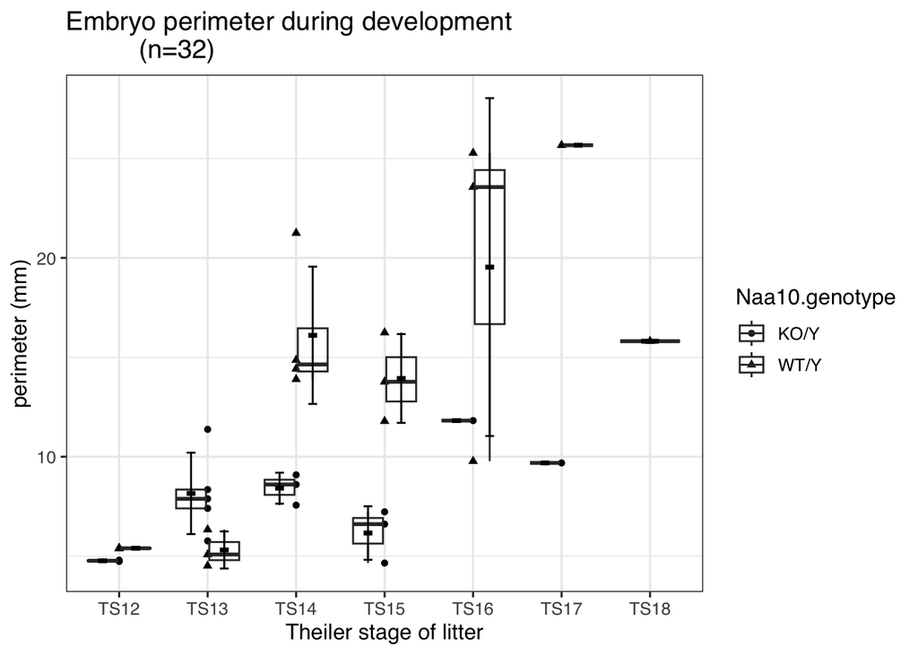

```r
library(ggplot2)
peri.plot <- ggplot(embryos, aes(x= Litter.Theiler.stage,y=perimeter..mm.,shape = Naa10.genotype))+
  geom_point(aes(shape = Naa10.genotype))+
     geom_boxplot(outlier.shape = NA,
               alpha = 0.1)+
    stat_summary(fun = mean, color = "black", position = position_dodge(0.75),width = 0.2,
             geom = "crossbar",
             show.legend = FALSE)+
   geom_errorbar(data = peri.summ, aes(ymin=perimeter..mm.-sd,
                     ymax=perimeter..mm.+sd),
                 width=.2,
                 position=position_dodge(0.75))+
  xlab("Theiler stage of litter")+
  ylab("perimeter (mm)")+
  ggtitle("Embryo perimeter during development
          (n=32)")+
  theme_bw(base_size = 12, base_family = "Helvetica")

peri.plot
```

## Area analysis

### Separate main effects of area, TS, and Naa10 genotype

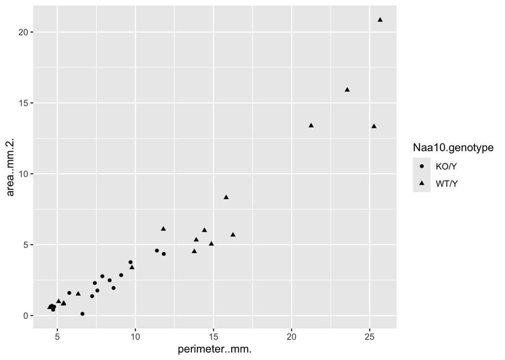

```r
area.peri.plot <- ggplot(embryos, aes(x= perimeter..mm.,
                    y=area..mm.2.,
                    shape = Naa10.genotype))+
  geom_point(aes(shape = Naa10.genotype))

area.peri.plot
```

### summary data

```r
library(Rmisc)
area.summ <- summarySE(data = embryos, "area..mm.2.",
          groupvars = c("Naa10.genotype","Litter.Theiler.stage"))
area.summ
```

| Naa10.genotype | Litter.Theiler.stage | N | area..mm.2. | sd | se | ci |
| --- | --- | --- | --- | --- | --- | --- |
| KO/Y | TS12 | 2 | 0.5177891 | 0.14899836 | 0.1053578 | 1.3386971 |
| KO/Y | TS13 | 5 | 2.7463300 | 1.11463529 | 0.4984801 | 1.3840025 |
| KO/Y | TS14 | 3 | 2.1875958 | 0.58360868 | 0.3369466 | 1.4497643 |
| KO/Y | TS15 | 3 | 0.7259740 | 0.62426594 | 0.3604201 | 1.5507626 |
| KO/Y | TS16 | 1 | 4.3485959 | NA | NA | NA |
| KO/Y | TS17 | 1 | 3.7643502 | NA | NA | NA |
| WT/Y | TS12 | 2 | 0.8425915 | 0.03460255 | 0.0244677 | 0.3108915 |
| WT/Y | TS13 | 3 | 1.0238916 | 0.47539544 | 0.2744697 | 1.1809477 |
| WT/Y | TS14 | 4 | 7.4399922 | 3.98293111 | 1.9914656 | 6.3377322 |
| WT/Y | TS15 | 3 | 5.4280486 | 0.81904010 | 0.4728730 | 2.0346084 |

[output cut: 3 more lines]

### area with separate main effects

```r
library(car)
area.lm <- lm(area..mm.2. ~ Litter.Theiler.stage+Naa10.genotype,embryos)
summary(area.lm)
```

```
##
## Call:
## lm(formula = area..mm.2. ~ Litter.Theiler.stage + Naa10.genotype,
##     data = embryos)
##
## Residuals:
##     Min      1Q  Median      3Q     Max
## -6.7684 -1.6362 -0.3204  1.6000  6.7259
##
## Coefficients:
##                          Estimate Std. Error t value Pr(>|t|)
## (Intercept)                -1.131      1.918  -0.589  0.56109
## Litter.Theiler.stageTS13    1.873      2.210   0.847  0.40515
## Litter.Theiler.stageTS14    4.250      2.258   1.882  0.07197 .
## Litter.Theiler.stageTS15    2.397      2.323   1.032  0.31251
## Litter.Theiler.stageTS16    7.654      2.567   2.982  0.00647 **
## Litter.Theiler.stageTS17   11.621      3.117   3.728  0.00104 **
## Litter.Theiler.stageTS18    5.828      4.078   1.429  0.16589
## Naa10.genotypeWT/Y          3.622      1.329   2.726  0.01178 *
## ---
## Signif. codes:  0 '***' 0.001 '**' 0.01 '*' 0.05 '.' 0.1 ' ' 1
##
## Residual standard error: 3.599 on 24 degrees of freedom
## Multiple R-squared:  0.5873, Adjusted R-squared:  0.4669
## F-statistic: 4.878 on 7 and 24 DF,  p-value: 0.001557
```

```r
summary(aov(area.lm))
```

```
##                      Df Sum Sq Mean Sq F value  Pr(>F)
## Litter.Theiler.stage  6  346.1   57.68   4.453 0.00365 **
## Naa10.genotype        1   96.3   96.27   7.431 0.01178 *
## Residuals            24  310.9   12.95
## ---
## Signif. codes:  0 '***' 0.001 '**' 0.01 '*' 0.05 '.' 0.1 ' ' 1
```

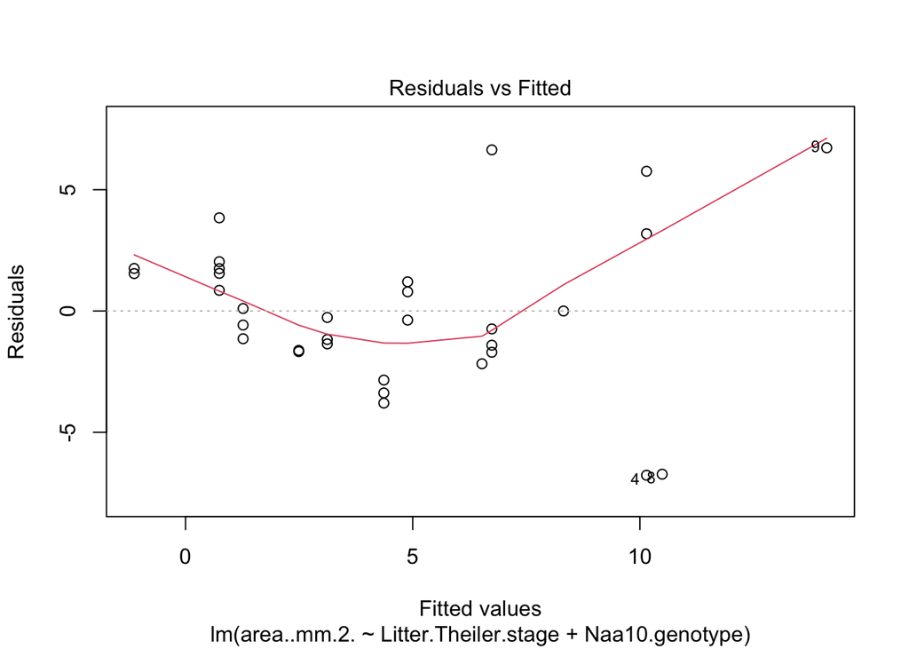

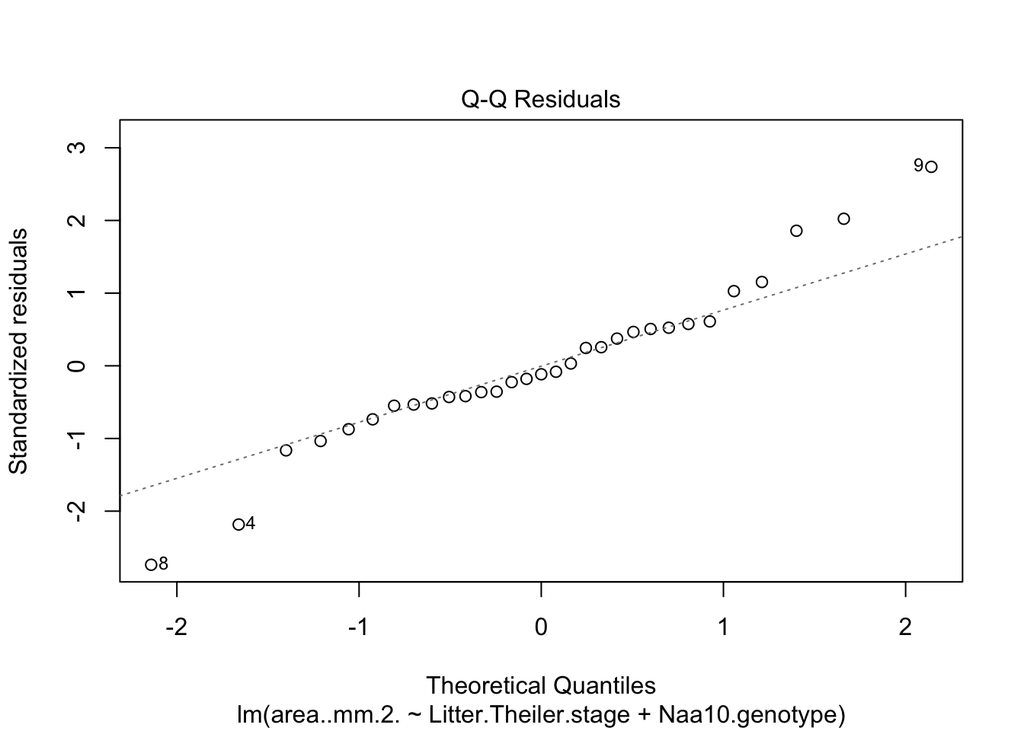

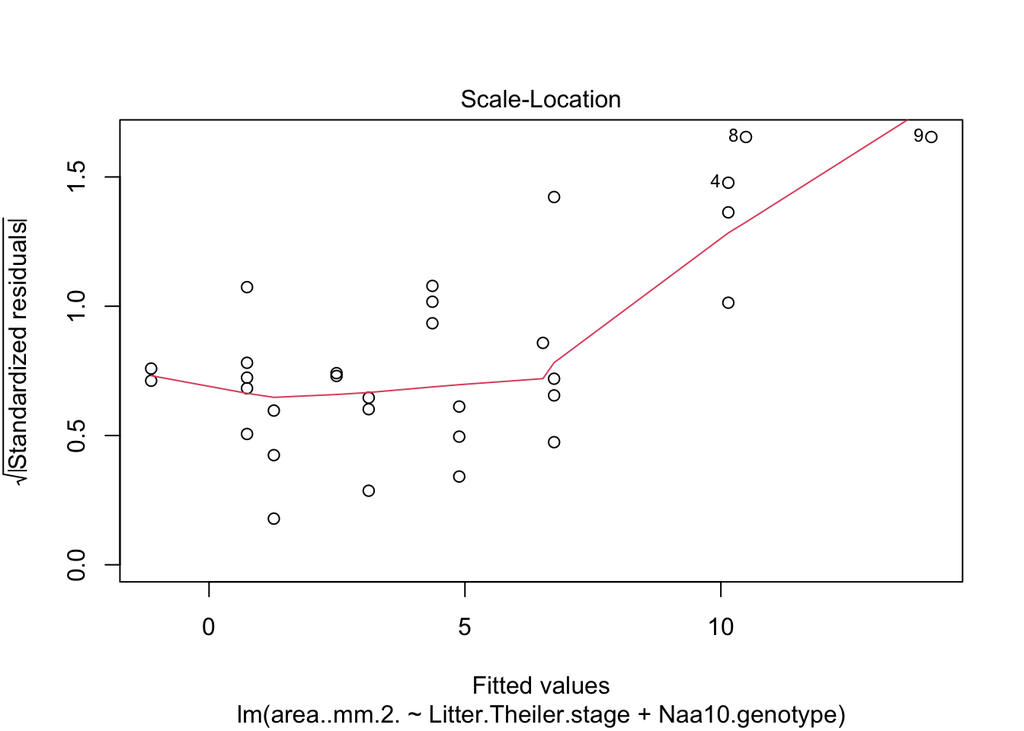

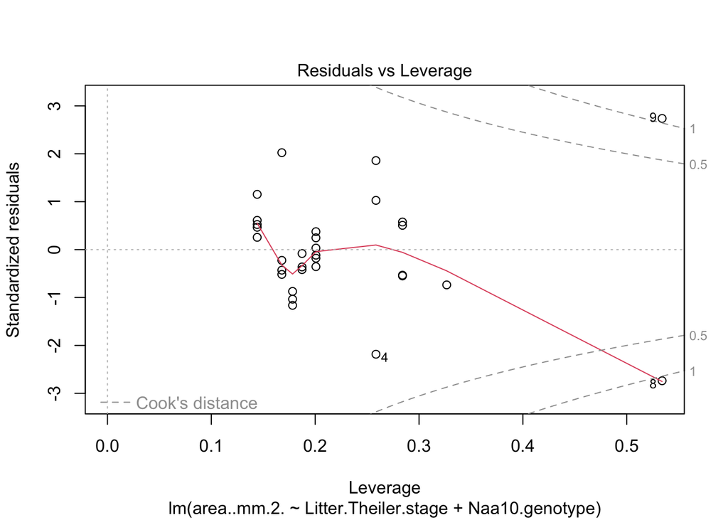

```r
plot(area.lm)
```

```r
library(car)
Anova(area.lm, type = "III")
```

|  | Sum Sq | Df | F value | Pr(>F) |
| --- | --- | --- | --- | --- |
| (Intercept) | 4.500331 | 1 | 0.3474117 | 0.56109007 |
| Litter.Theiler.stage | 279.987204 | 6 | 3.6023588 | 0.01089302 |
| Naa10.genotype | 96.266688 | 1 | 7.4314930 | 0.01177964 |
| Residuals | 310.893185 | 24 | NA | NA |

### Interaction of TS and Naa10 genotype

#### Balanced data?

```r
with(embryos,table(Litter.Theiler.stage,Naa10.genotype))
```

```
##                     Naa10.genotype
## Litter.Theiler.stage KO/Y WT/Y
##                 TS12    2    2
##                 TS13    5    3
##                 TS14    3    4
##                 TS15    3    3
##                 TS16    1    3
##                 TS17    1    1
##                 TS18    0    1
```

```r
library(car)
area.int.lm <- lm(area..mm.2. ~ Litter.Theiler.stage*Naa10.genotype,embryos)
summary(area.int.lm)
```

```
##
## Call:
## lm(formula = area..mm.2. ~ Litter.Theiler.stage * Naa10.genotype,
##     data = embryos)
##
## Residuals:
##     Min      1Q  Median      3Q     Max
## -7.4934 -0.4532 -0.0122  0.3108  5.9438
##
## Coefficients: (1 not defined because of singularities)
##                                             Estimate Std. Error t value
## (Intercept)                                   0.5178     1.9425   0.267
## Litter.Theiler.stageTS13                      2.2285     2.2984   0.970
## Litter.Theiler.stageTS14                      1.6698     2.5077   0.666
## Litter.Theiler.stageTS15                      0.2082     2.5077   0.083
## Litter.Theiler.stageTS16                      3.8308     3.3644   1.139
## Litter.Theiler.stageTS17                      3.2466     3.3644   0.965
## Litter.Theiler.stageTS18                      7.4765     3.3644   2.222
## Naa10.genotypeWT/Y                            0.3248     2.7471   0.118
## Litter.Theiler.stageTS13:Naa10.genotypeWT/Y  -2.0472     3.4016  -0.602
## Litter.Theiler.stageTS14:Naa10.genotypeWT/Y   4.9276     3.4566   1.426
## Litter.Theiler.stageTS15:Naa10.genotypeWT/Y   4.3773     3.5464   1.234
## Litter.Theiler.stageTS16:Naa10.genotypeWT/Y   6.1970     4.1962   1.477
## Litter.Theiler.stageTS17:Naa10.genotypeWT/Y  16.7488     4.7580   3.520
## Litter.Theiler.stageTS18:Naa10.genotypeWT/Y       NA         NA      NA
##                                             Pr(>|t|)
## (Intercept)                                  0.79268
## Litter.Theiler.stageTS13                     0.34442
## Litter.Theiler.stageTS14                     0.51350
## Litter.Theiler.stageTS15                     0.93471
## Litter.Theiler.stageTS16                     0.26902
## Litter.Theiler.stageTS17                     0.34669
## Litter.Theiler.stageTS18                     0.03861 *
## Naa10.genotypeWT/Y                           0.90712
## Litter.Theiler.stageTS13:Naa10.genotypeWT/Y  0.55439
## Litter.Theiler.stageTS14:Naa10.genotypeWT/Y  0.17022
## Litter.Theiler.stageTS15:Naa10.genotypeWT/Y  0.23215
## Litter.Theiler.stageTS16:Naa10.genotypeWT/Y  0.15611
## Litter.Theiler.stageTS17:Naa10.genotypeWT/Y  0.00229 **
## Litter.Theiler.stageTS18:Naa10.genotypeWT/Y       NA
## ---
## Signif. codes:  0 '***' 0.001 '**' 0.01 '*' 0.05 '.' 0.1 ' ' 1
##
## Residual standard error: 2.747 on 19 degrees of freedom
## Multiple R-squared:  0.8096, Adjusted R-squared:  0.6894
## F-statistic: 6.735 on 12 and 19 DF,  p-value: 0.0001376
```

```r
summary(aov(area.int.lm))
```

```
##                                     Df Sum Sq Mean Sq F value   Pr(>F)
## Litter.Theiler.stage                 6  346.1   57.68   7.643 0.000281 ***
## Naa10.genotype                       1   96.3   96.27  12.757 0.002036 **
## Litter.Theiler.stage:Naa10.genotype  5  167.5   33.50   4.440 0.007568 **
## Residuals                           19  143.4    7.55
## ---
## Signif. codes:  0 '***' 0.001 '**' 0.01 '*' 0.05 '.' 0.1 ' ' 1
```

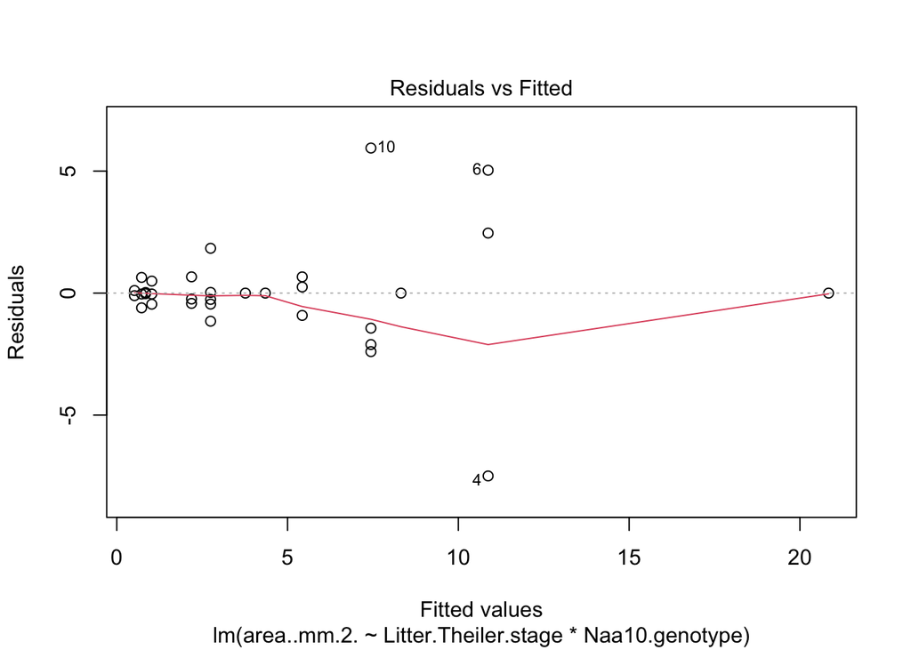

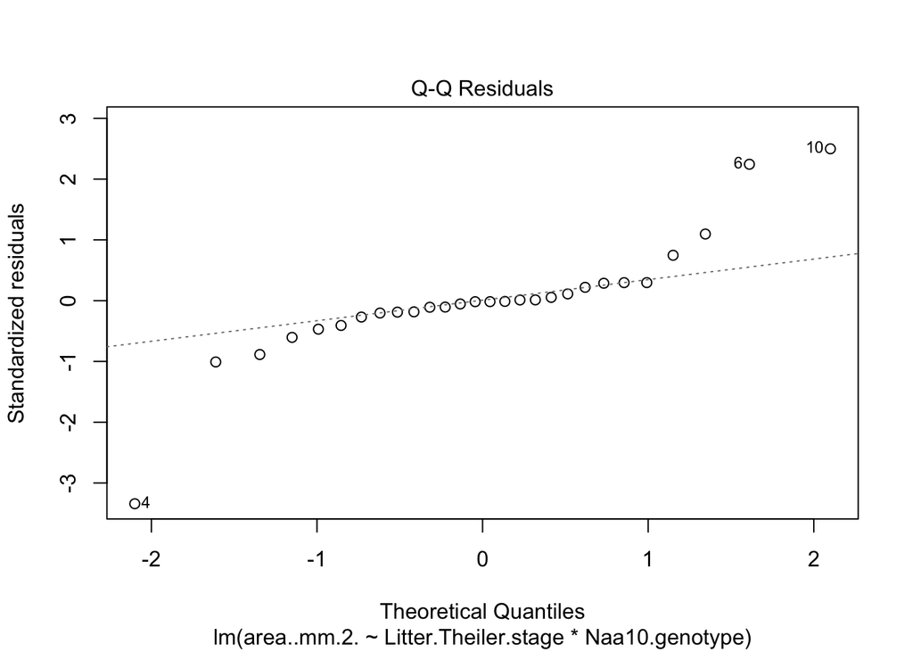

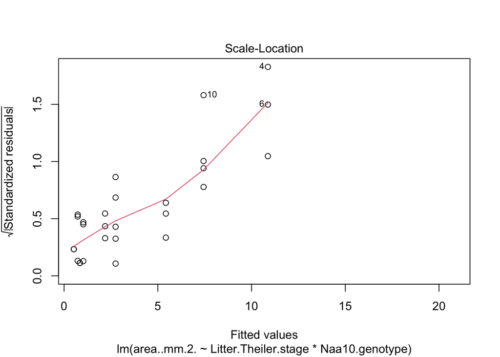

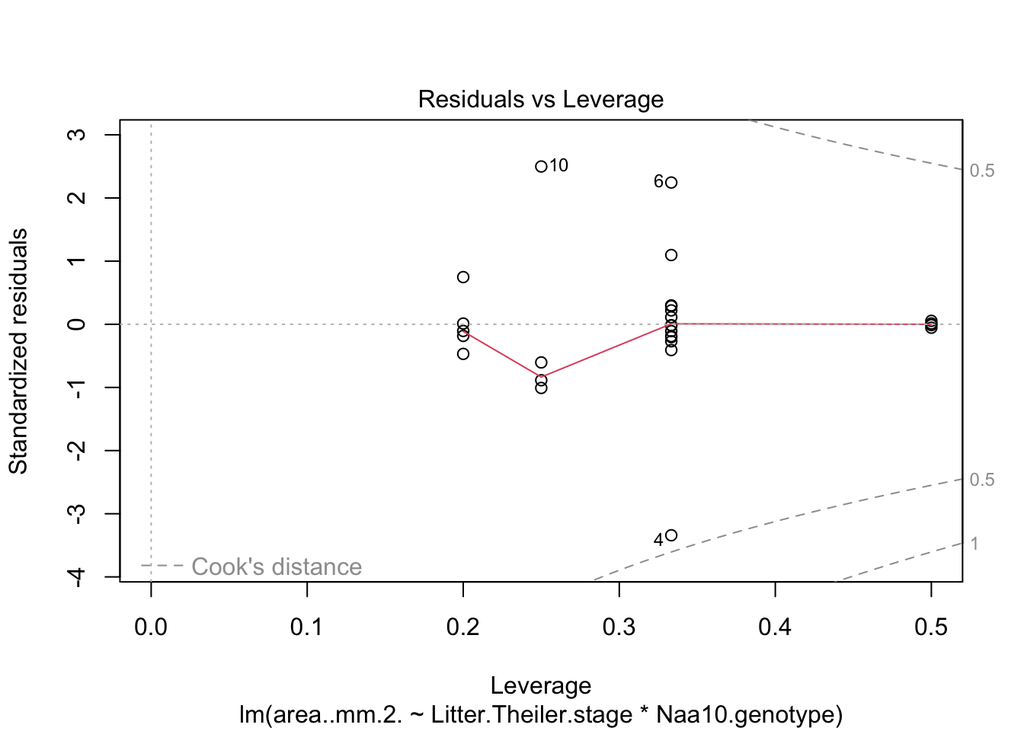

```r
plot(area.int.lm)
```

#### Type II ANOVA

```r
library(car)
Anova(area.int.lm, type = "II")
```

```
## Note: model has aliased coefficients
##       sums of squares computed by model comparison
```

|  | Sum Sq | Df | F value | Pr(>F) |
| --- | --- | --- | --- | --- |
| Litter.Theiler.stage | 279.98720 | 6 | 6.183748 | 0.0009923495 |
| Naa10.genotype | 96.26669 | 1 | 12.756774 | 0.0020355001 |
| Litter.Theiler.stage:Naa10.genotype | 167.51312 | 5 | 4.439598 | 0.0075679526 |
| Residuals | 143.38007 | 19 | NA | NA |

#### Type III ANOVA

```r
library(car)
Anova(area.int.lm, type = "III",singular.ok = TRUE)
```

```
## Note: model has aliased coefficients
##       sums of squares computed by model comparison
```

|  | Sum Sq | Df | F values | Pr(>F) |
| --- | --- | --- | --- | --- |
| Litter.Theiler.stage | 20.6076275 | 5 | 0.54616367 | 0.739227478 |
| Naa10.genotype | 0.1054966 | 1 | 0.01397987 | 0.907121323 |
| Litter.Theiler.stage:Naa10.genotype | 167.5131174 | 5 | 4.43959788 | 0.007567953 |
| Residuals | 143.3800680 | 19 | NA | NA |

### Area viz

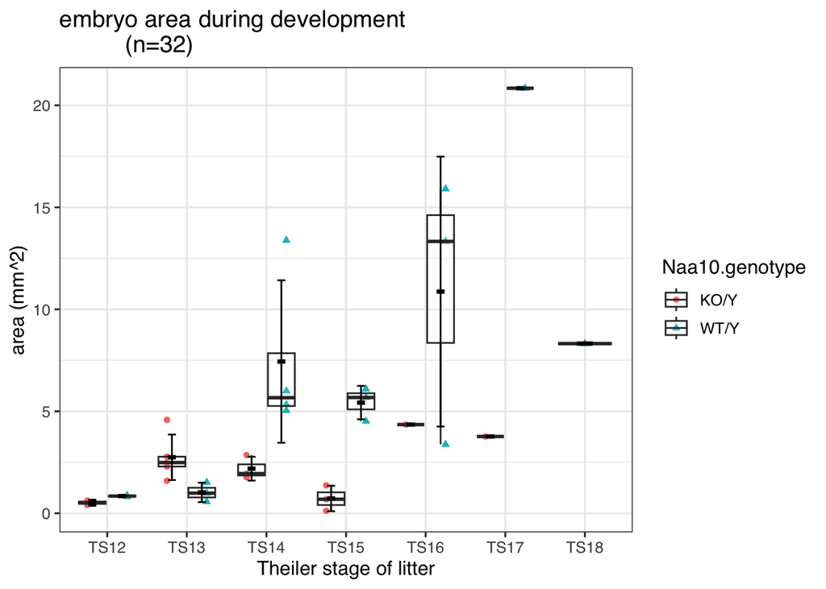

```r
library(ggplot2)

area.plot <- ggplot(embryos, aes(x= Litter.Theiler.stage,y=area..mm.2., shape = Naa10.genotype))+
  geom_point(aes(color = Naa10.genotype),position = position_dodge(1),alpha = 1000)+
     geom_boxplot(outlier.shape = NA,
               alpha = 0.1)+
    stat_summary(fun = mean, color = "black", position = position_dodge(0.75),width = 0.2,
             geom = "crossbar",
             show.legend = FALSE)+
   geom_errorbar(data = area.summ, aes(ymin=area..mm.2.-sd,
                     ymax=area..mm.2.+sd),
                 width=.2,
                 position=position_dodge(0.75))+
  xlab("Theiler stage of litter")+
  ylab("area (mm^2)")+
  ggtitle("embryo area during development
          (n=32)")+
  theme_bw(base_size = 12, base_family = "Helvetica")

area.plot
```

## alternative model?

```r
library(car)
alt.lm <- lm(area..mm.2. ~ perimeter..mm.*Litter.Theiler.stage*Naa10.genotype,embryos)
summary(area.lm)
```

```
##
## Call:
## lm(formula = area..mm.2. ~ Litter.Theiler.stage + Naa10.genotype,
##     data = embryos)
##
## Residuals:
##     Min      1Q  Median      3Q     Max
## -6.7684 -1.6362 -0.3204  1.6000  6.7259
##
## Coefficients:
##                          Estimate Std. Error t value Pr(>|t|)
## (Intercept)                -1.131      1.918  -0.589  0.56109
## Litter.Theiler.stageTS13    1.873      2.210   0.847  0.40515
## Litter.Theiler.stageTS14    4.250      2.258   1.882  0.07197 .
## Litter.Theiler.stageTS15    2.397      2.323   1.032  0.31251
## Litter.Theiler.stageTS16    7.654      2.567   2.982  0.00647 **
## Litter.Theiler.stageTS17   11.621      3.117   3.728  0.00104 **
## Litter.Theiler.stageTS18    5.828      4.078   1.429  0.16589
## Naa10.genotypeWT/Y          3.622      1.329   2.726  0.01178 *
## ---
## Signif. codes:  0 '***' 0.001 '**' 0.01 '*' 0.05 '.' 0.1 ' ' 1
##
## Residual standard error: 3.599 on 24 degrees of freedom
## Multiple R-squared:  0.5873, Adjusted R-squared:  0.4669
## F-statistic: 4.878 on 7 and 24 DF,  p-value: 0.001557
```

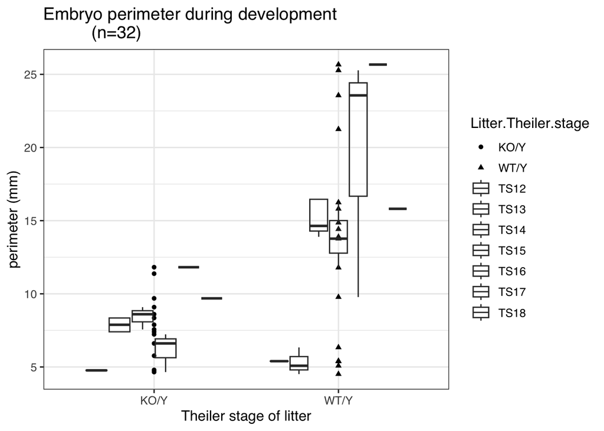

```r
library(ggplot2)
litter.plot <- ggplot(embryos, aes(x= Naa10.genotype,y=perimeter..mm.,shape = Litter.Theiler.stage))+
  geom_point(aes(shape = Naa10.genotype))+
     geom_boxplot(outlier.shape = NA,
               alpha = 0.1)+
  xlab("Theiler stage of litter")+
  ylab("perimeter (mm)")+
  ggtitle("Embryo perimeter during development
          (n=32)")+
  theme_bw(base_size = 12, base_family = "Helvetica")

litter.plot
```

Next (2024-04-23 11:58 AM): 1) Finish measuring remaining embryos

2. May need to omit females because of insufficient numbers (delayed development more sporadic in females?)
3. Can do two-sample t-tests if I plot Theiler stages individually or ANOVA if I want to have all Theiler stages on plot

Updates (2024-04-29 11:55 AM) 1) Find matching number of controls for TS15 Naa10 KO/Y embryos probably from another litter 2) ID 1-2 TS16 Naa10 KO/Y embryos if needed. 3) May need another column variable (e.g., delayed or normal developing) 4) May bucket TS12-TS13. Or pair TS14-15, TS16-17, TS17-18

Only one TS16 litter, so may need to bucket with TS17 and thus bucket as described 2024-04-29 item 4.

Naa10 KO/Y embryos may indeed be delayed developing, but also intrinsically smaller.